# slide_deck_template slides

## The distribution of average of total score for both gender

We start off by plotting the distribution and the boxplot to check that both gender are doing equally well, with female doing very slightly better than male

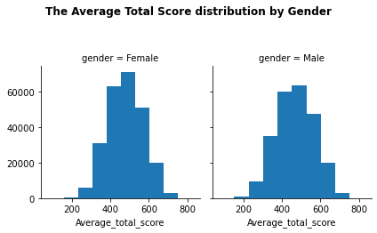

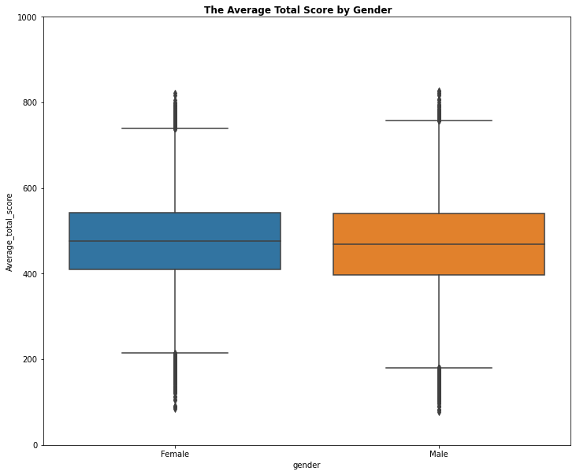

## The distribution and proportion of the parents level of education

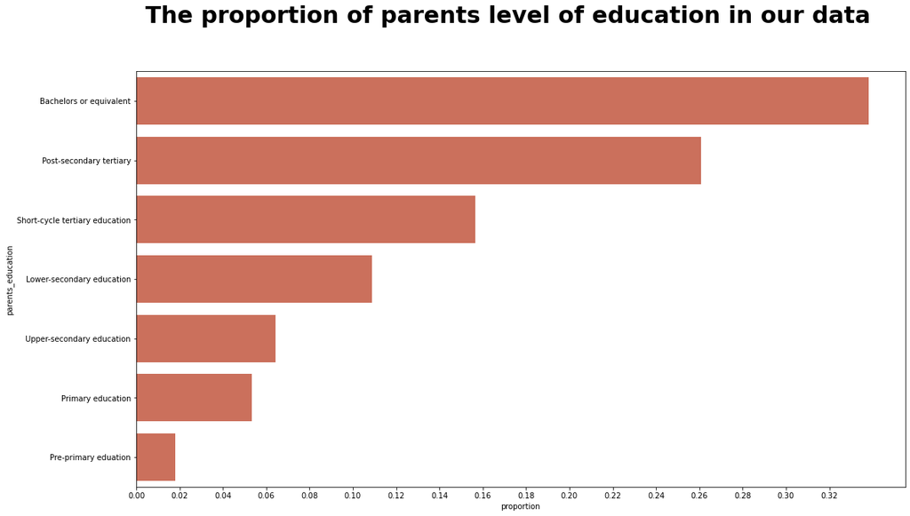

## The proportion of attitude features with their level of agreement

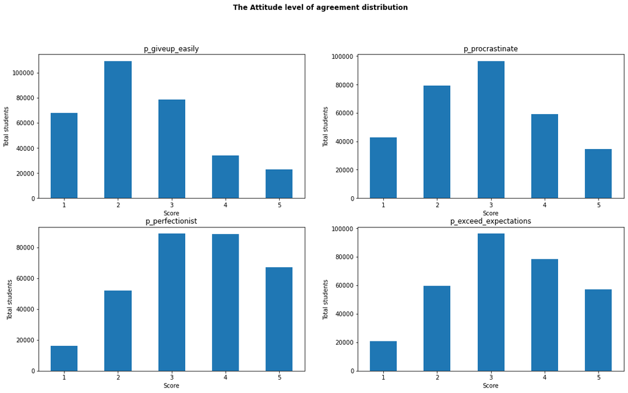

## The average total score across parents level of education

When comparing the parents level of education to the average total score, there is a strong relationship between these two variables. The higher the education of the parents, the better their performances are in school through the total average of all three subjects

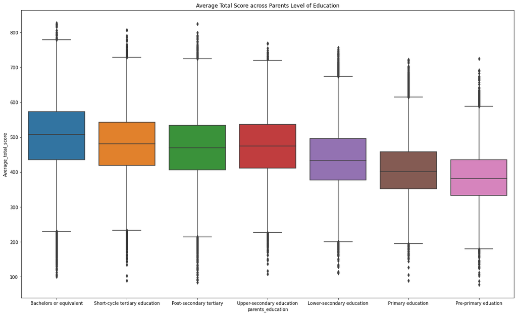

## Students attitude agreement with total study time & average total score

As for the the level of agreement to the attitude variables, we found a slight interaction and correlation where the more positive attitude they agreed to, the higher the score they have and the more study time they put in

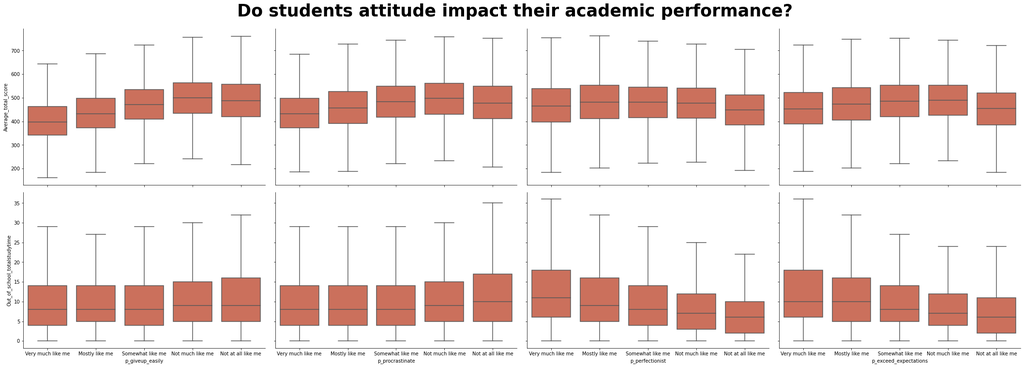

In the multivariate exploration, we will look whether these categorical variables still be significant when more categorical varibale added.

## Student's attitude agreement with average total score and parental presence

The boxplot of the multivariable reveal much more. As expected, students who have parents scored significantly higher in average regardless the attitude they possess in their academic life

[figure not shown]

## The relationship of parental presence with average total score and out of school study time

The same case for this plot where in average, the students with either parents at home scored higher but spend almost around the same amount of time in studying outside of school.

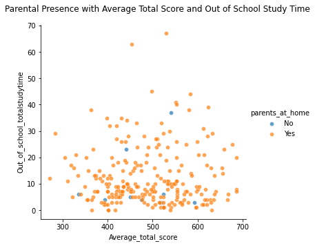

## Key insights and summary

When comparing the parents level of education to the average total score, there is a strong relationship between these two variables. The higher the education of the parents, the better their performances are in school through the total average of all three subjects. As for the the level of agreement to the attitude variables, we found a slight interaction and correlation where the more positive attitude they agreed to, the higher the score they have and the more study time they put in. When adding another variable in, which is the parental presence at home, it seems that it does not have a strong effect to the attitude but rather to their academic performance. As to both learning time and study time, the students put in almost the same amount of time regardless either parents are home. The level of education of the parents and their presence are big predictor of success in student's academic pursuit.